```python
%matplotlib inline
import numpy as np
import pandas as pd
import matplotlib.pyplot as plt
import sys
from scipy.stats import norm
sys.path.append("..")
from script.static_SAX import znormalization,paa_transform,sax_transform
```

```python
import seaborn as sns
sns.set_style("whitegrid")
```

# First studies of EEG signals

In order to do some initial analysis of EEG signals we download the UCI [EEG Eye State Data Set](https://archive.ics.uci.edu/ml/datasets/EEG+Eye+State#).

- Dataset obtained from a continuous EEG measurement.
- EEG technology used: `Emotiv EEG Neuroheadset`.
- Duration: 117 seconds.
- Last column: Eye state detected using a camera and added manually. (1: eye-closed, 0: eye-opened)
- Values in chronological order (from the top to the bottom of the dataset)
- Since the dataset contains 14980 points, the frequency of measures is of 128 points per second, which is close to 10 times the [frequency of Beta wave](http://emedicine.medscape.com/article/1139332-overview#a2).

# Filtering outliers

The EEG records contain some unusually high values. It is better to filter these measures in order to have a better repartition of the data points after the z-score standardization

```python
def clean_outlier(column):
    mean_column = column.mean()
    std_column = column.std()
    column[column > mean_column+3*std_column] = mean_column+3*std_column
    column[column < mean_column-3*std_column] = mean_column-3*std_column
    return column
```

# Load the dataset

- Use the Pandas library to read the csv file
- Separate the records and the labels

```python
eeg = pd.read_csv("../data/EEG_Eye_State.arff",comment="@",header=None)
Y = eeg[eeg.columns[-1]]
X = eeg.drop(eeg.columns[-1],1)
X = X.apply(clean_outlier)
```

# Standardize the dataset

```
(-3, 3)
```

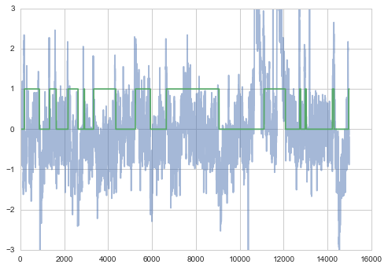

```python
eeg_id = 2
z_eeg = znormalization(X)
plt.plot(range(Y.size),z_eeg[eeg_id],alpha=0.5)
plt.plot(range(Y.size),Y)
plt.ylim([-3,3])
```

# Compute the Piecewise Aggregate Approximation (PAA)

The PAA algorithm applies to the time series the following operations:

```
+ Segments the time series into equal parts
+ Stores the average value for each part
```

```
(-3, 3)
```

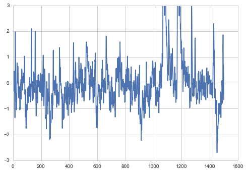

```python
eeg_id = 2
split_eeg = paa_transform(z_eeg, 1500)
plt.plot(range(split_eeg[:,eeg_id].size),split_eeg[:,eeg_id])
plt.ylim([-3,3])
```

# Compute the Symbolic Aggregate approXimation (SAX)

The SAX algorithm applies to the time series the following operations:

```
+ Applies the PAA algorithm
+ Converts the PAA results into symbols
```

```python
sax_eeg = sax_transform(X, 1500, 30, False)
```

# From PAA to SAX representation

```
(-2.5, 2.5)
```

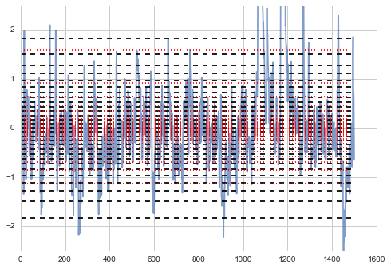

```python
alphabet_sz=30
eeg_id = 2
percentils2 = np.percentile(split_eeg,np.linspace(1./alphabet_sz,
                                          1-1./alphabet_sz,
                                          alphabet_sz-1)*100)

percentils = norm.ppf(np.linspace(1./alphabet_sz,
                                          1-1./alphabet_sz,
                                          alphabet_sz-1))
plt.plot(range(split_eeg[:,eeg_id].size),split_eeg[:,eeg_id],alpha=0.7)
for percentil in percentils:
    plt.plot((0, split_eeg[:,eeg_id].size), (percentil, percentil), 'k--')
for percentil in percentils2:
    plt.plot((0, split_eeg[:,eeg_id].size), (percentil, percentil), 'r:')
plt.ylim([-2.5,2.5])
```

# Graphic representation of the SAX transformation

- Each symbol is denoted by a specific color, a grandient of colors has been chosen since the different symbolos could be considered as ordered

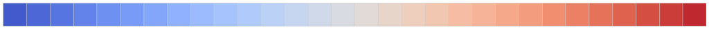

```python
palette = sns.color_palette("coolwarm", 30)
sns.palplot(sns.color_palette("coolwarm", 30))
```

# Plot of the SAX representation of the EEG

- Each one of the 14 EEG records is converted to its SAX representation
- The palette defined previously is used to represent the symbol at each time step
- Notice that the different EEG records are more or less correlated

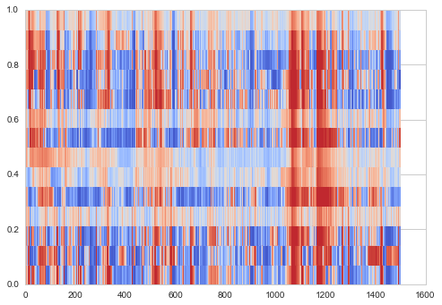

```python
step = 1./sax_eeg.shape[1]
for k,eeg_id in enumerate(range(sax_eeg.shape[1])):
    for i,val in enumerate(sax_eeg[:,eeg_id]):
        plt.plot((i,i), (k*step,(k+1)*step), color=palette[val])
```